# Fenómenos físicos asociados

Resuelve estas cuestiones o problemas en la carpeta de modo prolijo

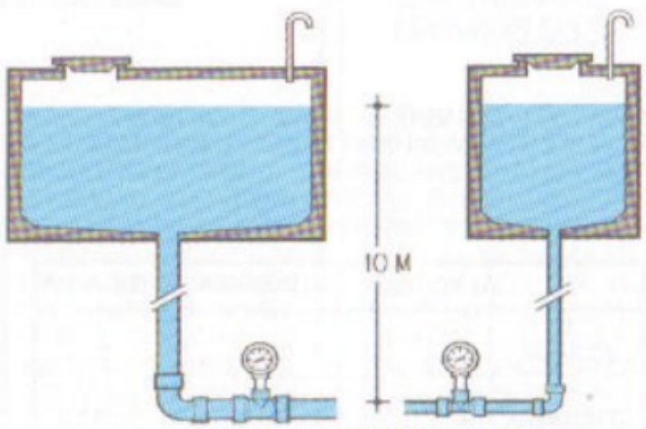

- 5- ¿Qué presión hidrostática hay en la ducha antes de abrir la canilla? Expresarla en kgf/cm2 y en m.c.a (metros de columna de agua). Equivalencia: `1 Kgf/cm2 = 10 m.c.a.` ¿Cómo es la presión de la ducha respecto a la recién calculada cuando se abre la canilla?

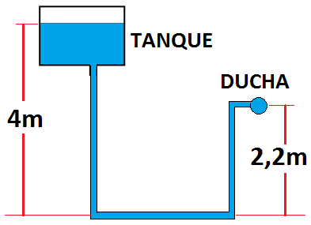

- 6- Responder lo siguiente referido a la figura:
  - a- Explicar como son las presiones hidrostáticas en ambas canillas (iguales/ distintas) y el porqué
  - b- Si se abren ambas canillas. Explicar como son las presiones dinámicas en ambas canillas y el porqué
  - c- Suponga que entre el nivel del agua del tanque y las canillas hay 20 metros de altura. ¿Cuál es la presión hidrostática en cada canilla? Calcularla en Kgf/cm2, m.c.a. y PSI.

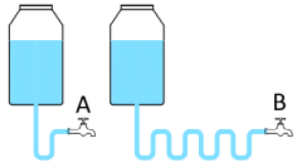

- 7- Un problema de la vida real de difícil solución que también puede suceder en tu casa. La llamada **humedad de cimientos** sucede comunmente en contrucciones antiguas en donde los cimientos están en contacto con napas de agua subterránea o simplemente con la humedad de la tierra en donde se apoyan. Cuando sucede esto muchas veces aparecen manchas en la parte superior de la pared.
  - a- Explique por que sube la humedad hasta esos lugares superiores.
  - b- Investigue y explique en dos o tres renglones como se forma el salitre.
  - c- A pesar de que se usan varias tecnologías para contrarestar la humedad de cimientos siempre se escuchan comentarios de que después de un tiempo la humedad vuelve a aparecer y a destruir la pintura donde se había reparado. Esto sucede sobre todo en contrucciones antiguas donde las paredes no se contruyeron orginalmente usando protecciones contra la humedad. Al parecer es un problema de difícil solución en estos casos. Sin embargo hay una tecnología llamada “electroósmosis” que parece ser una muy buena opción si se puede hacer el gasto. Explique brevemente en que consiste esta tecnológía. (4 o 5 renglones, explicar simplemente lo esencial).